# Graphics of final accuracies using static classification over original images and composites

William Martinez

3 de noviembre de 2018

# Overall accuracies per image

The following graphic presents a overview of the overall accuracies for the classification of 15 classes of COS per imagery available suring 2017; implementing random forest classifier. I used two versions of the COS training data according with the analysis of NDVI over time, one without cleaning process and another implementing the interquantile range analysis to remove outliers in the dataset. Although the graphics are done by using ggplot2 in R, the results are derived from a set of scripts done in python (visit ToolPython). Each classification account with 13 bands B02: Blue; B03:Green; B04: Red, B05,B06,B07: Vegetation red edge; B08: NIR; B11, B12: SWIR; B8A: Narrow NIR; NDVI; ZDEM; ZSLOPE.

```r
path_accuracies = "D:\\TESISMASTER\\csv\\accuracies_staticmodel.txt"
#reading files
df_accuracies =  read.table(path_accuracies,sep = "\t", header = TRUE)
output1= NULL
for (k in unique(df_accuracies$Model)){
  index  = which(df_accuracies$Model == k)
  df_accuracies_query = df_accuracies[index,-1]
  output0 = NULL
  for(i in 1:dim(df_accuracies_query)[2]){
    name_column = colnames(df_accuracies_query)[i]
    year = substr(name_column,4,7)
    month = substr(name_column,8,9)
    day = substr(name_column,10,11)
    fecha = as.character(as.Date(paste0(year,"/",month,"/",day), "%Y/%m/%d"))
    df0 = data.frame(k, letters[i] ,fecha,df_accuracies_query[,i])
    output0 = rbind(output0, df0)
  }
  output1 =  rbind(output1,output0)
}
colnames(output1) = c("Model","id","time","Accuracy")
```

As I expected in the analysis of NDVI over the time the periods with better accuracies are between June and October since large part of the visible NDVI variability was during these months. Therefore, this graphic becomes in the baseline for this thesis. That is, any better accuracy that can imply the integration of the temporal domain must be compared with the present graphic.

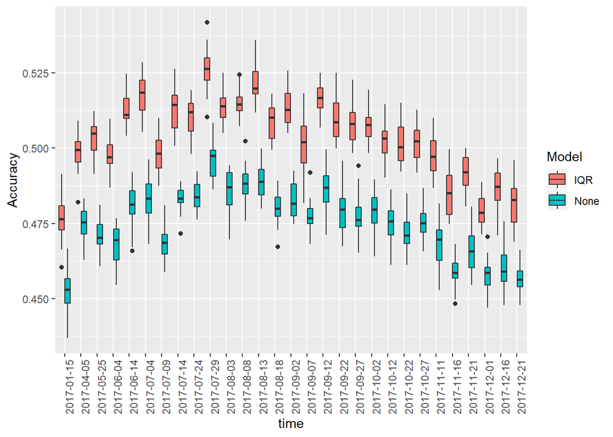

```r
# library
library(ggplot2)
# grouped boxplot
ggplot(output1, aes(x=time, y=Accuracy, fill=Model)) +
   theme(axis.text.x = element_text(angle = 90, hjust = 1)) +
    geom_boxplot()
```

# Overall accuracies per composites

The composites are also part of the scripts in Python that I am still documenting. However, the construction of this images are based in maximum NDVI per season. That is, from a set of images that belong for example to winter -each one composed by 10 spectral bands besides NDVI- it is extracted the maximum NDVI, so that, the pixel with the maximun NDVI is the reference in time to retrieve the rest of the pixels with spectral domain. In the same frame of the previous implementation using individual images we have the following accuracies.

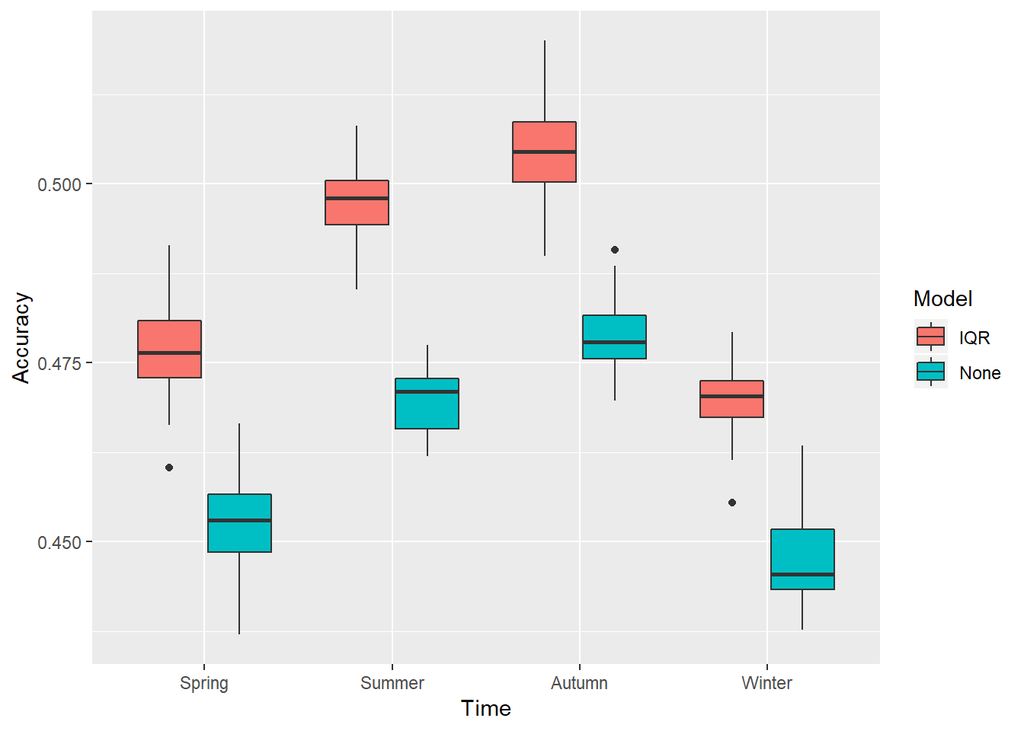

```r
path_accuracies_comp = "D:\\TESISMASTER\\csv\\accuracies_staticmodel_composites.txt"
#reading files
df_accuracies_comp =  read.table(path_accuracies_comp,sep = "\t", header = TRUE)
df_accuracies_comp$Time = factor(df_accuracies_comp$Time, c("Spring","Summer",'Autumn','Winter'))
# library
library(ggplot2)
# grouped boxplot
ggplot(df_accuracies_comp, aes(x=Time, y=Accuracy, fill=Model)) +
    geom_boxplot()
```

The best accuracies implementing composites are for the season of Autumn. An early comparition based in overall accuracies show a better performance in the individual classification.

### Accuracies Agricultural areas

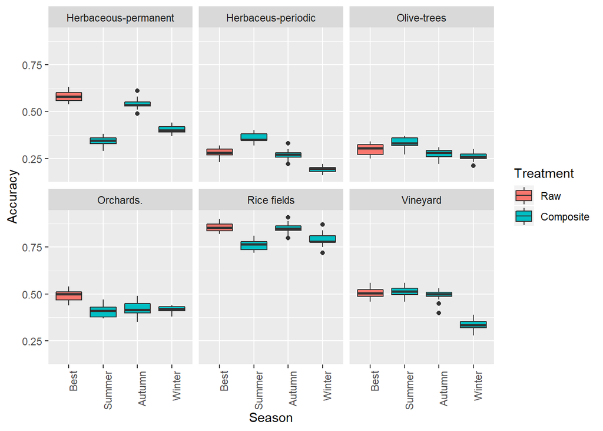

```r
file_class_composites = 'D:\\TESISMASTER\\csv\\Accuracies_perclass_composites.txt'
df_accuracies_pclass =  read.table(file_class_composites,sep = "\t", header = TRUE)
df_accuracies_pclass$Treatment = factor(df_accuracies_pclass$Treatment, c("Raw","Composite"))
df_accuracies_pclass$Season = factor(df_accuracies_pclass$Season ,
                                     c("Best","Summer","Autumn","Winter"))
#graphic
queary_df = df_accuracies_pclass[df_accuracies_pclass$Landcover %in% c("Rice fields", "Herbaceus-periodic","Vineyard","Orchards.","Olive-trees","Herbaceous-permanent"),]
ggplot(queary_df, aes(x=Season, y=Accuracy, fill=Treatment)) +
  theme(axis.text.x = element_text(angle = 90, hjust = 1)) +
  geom_boxplot() +
  facet_wrap(~ Landcover)
```

### Forest and seminatural areas

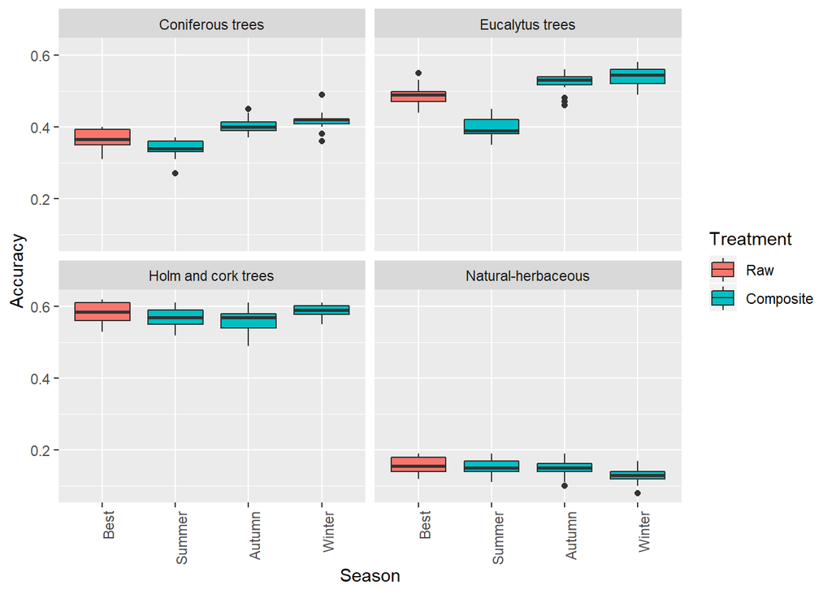

```r
#graphic
queary_df = df_accuracies_pclass[df_accuracies_pclass$Landcover %in% c("Holm and cork trees", "Eucalytus trees","Coniferous trees","Natural-herbaceous"),]
ggplot(queary_df, aes(x=Season, y=Accuracy, fill=Treatment)) +
  theme(axis.text.x = element_text(angle = 90, hjust = 1)) +
  geom_boxplot() +
  facet_wrap(~ Landcover)
```

### Water bodies and urban areas

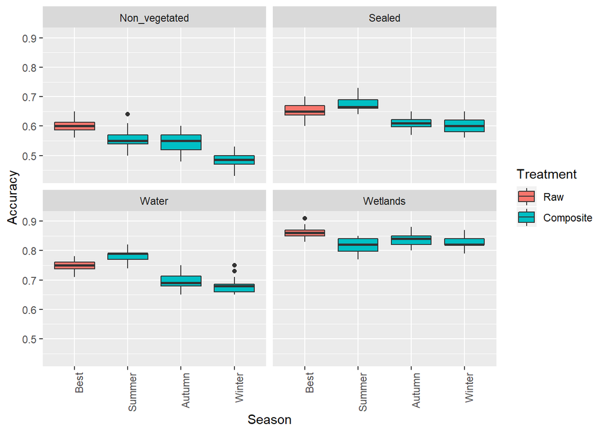

```r
#graphic
queary_df = df_accuracies_pclass[df_accuracies_pclass$Landcover %in% c("Sealed", "Non_vegetated","Wetlands","Water"),]
ggplot(queary_df, aes(x=Season, y=Accuracy, fill=Treatment)) +
  theme(axis.text.x = element_text(angle = 90, hjust = 1)) +
  geom_boxplot() +
  facet_wrap(~ Landcover)
```